# More linear modelling

28 August, 2020

## Linear modelling continued…

## Multiple Linear Regression

### Additive model

\[response = intercept + Predictor1 + Predictor2\] \[y_i=\beta_0+\beta_1x_{i1}+\beta_2x_{i2}+...+\beta_jx_{ij}+\epsilon_i\] OR \[y_i=\beta_0+\sum^N_{j=1:n}{\beta_j x_{ji}}+\epsilon_i\]

## Multiple Linear Regression

### Additive model

\[growth = intercept + Predictor1 + Predictor2\]

\[y_i=\beta_0+\beta_1x_{i1}+\beta_2x_{i2}+...+\beta_jx_{ij}+\epsilon_i\]  
- effect of one predictor holding the other(s) constant

## Multiple Linear Regression

### Additive model

\(growth = intercept + Predictor1 + Predictor2\)

\(y_i=\beta_0+\beta_1x_{i1}+\beta_2x_{i2}+...+\beta_jx_{ij}+\epsilon_i\)

| Y | X1 | X2 |
| --- | --- | --- |
| 3.0 | 22.7 | 0.9 |
| 2.5 | 23.7 | 0.5 |
| 6.0 | 25.7 | 0.6 |
| 5.5 | 29.1 | 0.7 |
| 9.0 | 22.0 | 0.8 |
| 8.6 | 29.0 | 1.3 |
| 12.0 | 29.4 | 1.0 |

## Multiple Linear Regression

### Additive model

\[ \begin{alignat*}{1} 3~&=~(1\times\beta_0) ~&+~(\beta_1\times22.7) ~&+~(\beta_2\times0.9)~&+~\varepsilon_1\\ 2.5~&=~(1\times\beta_0) ~&+~(\beta_1\times23.7) ~&+~(\beta_2\times0.5)~&+~\varepsilon_2\\ 6~&=~(1\times\beta_0) ~&+~(\beta_1\times25.7) ~&+~(\beta_2\times0.6)~&+~\varepsilon_3\\ 5.5~&=~(1\times\beta_0) ~&+~(\beta_1\times29.1) ~&+~(\beta_2\times0.7)~&+~\varepsilon_4\\ 9~&=~(1\times\beta_0) ~&+~(\beta_1\times22) ~&+~(\beta_2\times0.8)~&+~\varepsilon_5\\ 8.6~&=~(1\times\beta_0) ~&+~(\beta_1\times29) ~&+~(\beta_2\times1.3)~&+~\varepsilon_6\\ 12~&=~(1\times\beta_0) ~&+~(\beta_1\times29.4) ~&+~(\beta_2\times1)~&+~\varepsilon_7\\ \end{alignat*} \]

## Multiple Linear Regression

### Multiplicative model

\[growth = intercept + Pred1 + Pred2 + Pred1\times Pred2\]

\[y_i=\beta_0+\beta_1x_{i1}+\beta_2x_{i2}+\beta_3x_{i1}x_{i2}+...+\epsilon_i\]

## Multiple Linear Regression

### Multiplicative model

\[ \begin{alignat*}{1} 3~&=~(1\times\beta_0) ~&+~(\beta_1\times22.7) ~&+~(\beta_2\times0.9)~&+~(\beta_3\times22.7\times0.9)~&+~\varepsilon_1\\ 2.5~&=~(1\times\beta_0) ~&+~(\beta_1\times23.7) ~&+~(\beta_2\times0.5)~&+~(\beta_3\times23.7\times0.5)~&+~\varepsilon_2\\ 6~&=~(1\times\beta_0) ~&+~(\beta_1\times25.7) ~&+~(\beta_2\times0.6)~&+~(\beta_3\times25.7\times0.6)~&+~\varepsilon_3\\ 5.5~&=~(1\times\beta_0) ~&+~(\beta_1\times29.1) ~&+~(\beta_2\times0.7)~&+~(\beta_3\times29.1\times0.7)~&+~\varepsilon_4\\ 9~&=~(1\times\beta_0) ~&+~(\beta_1\times22) ~&+~(\beta_2\times0.8)~&+~(\beta_3\times22\times0.8)~&+~\varepsilon_5\\ 8.6~&=~(1\times\beta_0) ~&+~(\beta_1\times29) ~&+~(\beta_2\times1.3)~&+~(\beta_3\times29\times1.3)~&+~\varepsilon_6\\ 12~&=~(1\times\beta_0) ~&+~(\beta_1\times29.4) ~&+~(\beta_2\times1)~&+~(\beta_3\times29.4\times1)~&+~\varepsilon_7\\ \end{alignat*} \]

## Centering data

## Multiple Linear Regression

### Centering

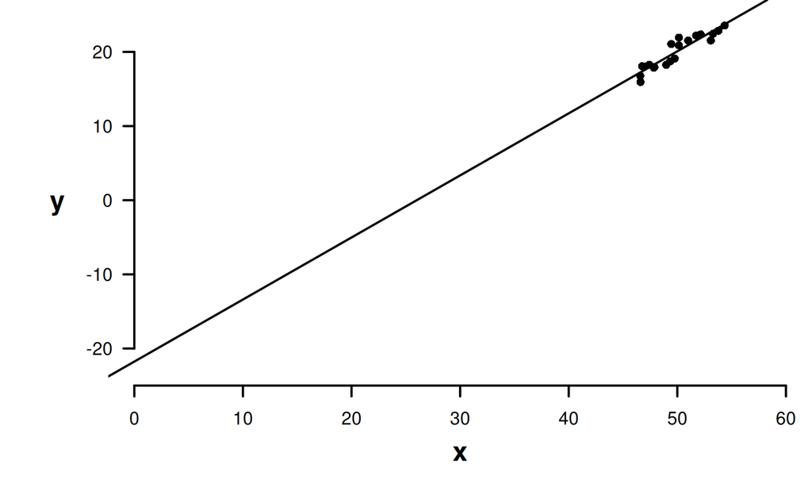

## Multiple Linear Regression

### Centering

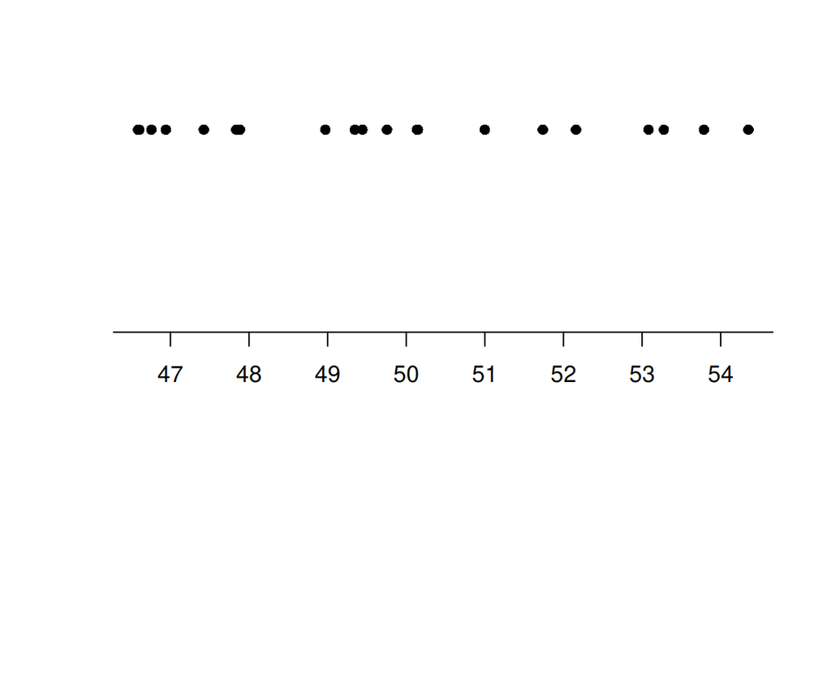

## Multiple Linear Regression

### Centering

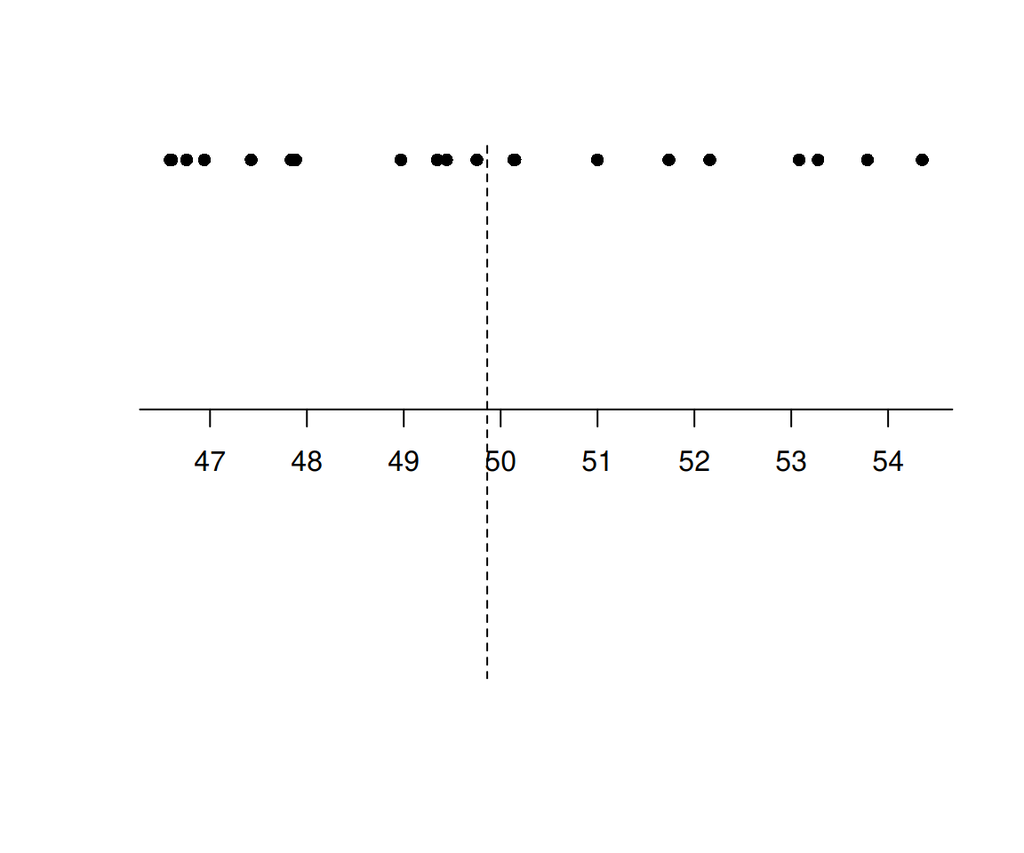

## Multiple Linear Regression

### Centering

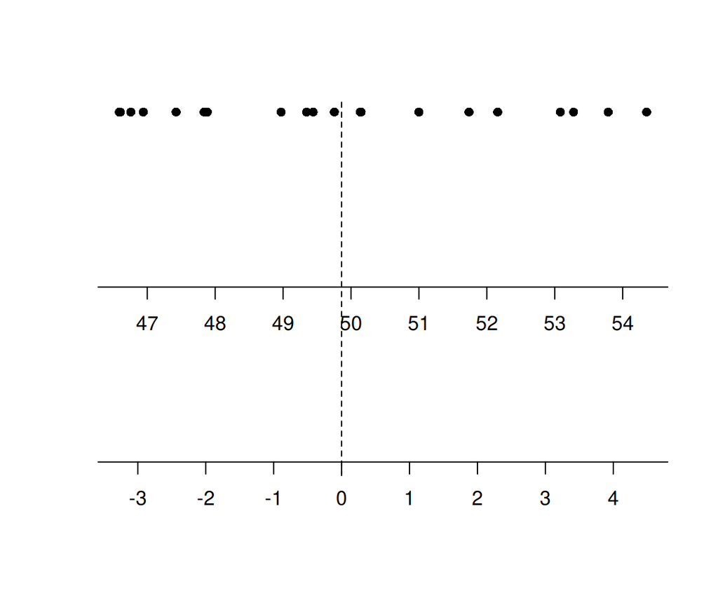

## Multiple Linear Regression

### Centering

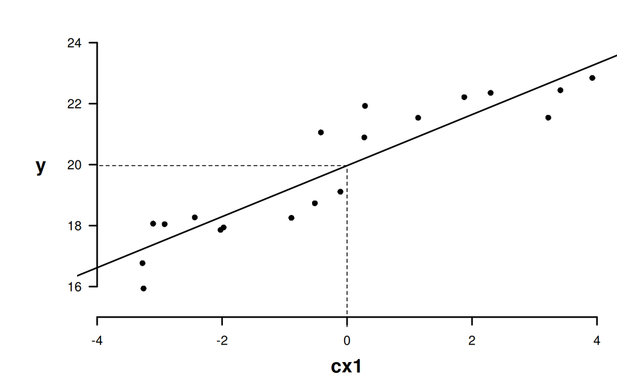

## Assumptions

## Multiple Linear Regression

### Assumptions

Normality, homog., linearity

[figure not shown]

## Multiple Linear Regression

### Assumptions

(multi)collinearity

[figure not shown]

## Multiple Linear Regression

### Variance inflation

Strength of a relationship \[ R^2 \] Strong when \(R^2 \ge 0.8\)

## Multiple Linear Regression

### Variance inflation

\[ var.inf = \frac{1}{1-R^2} \] Collinear when \(var.inf >= 5\)

Some prefer \(>3\)

## Multiple Linear Regression

### Assumptions

(multi)collinearity

```r
library(car)
# additive model - scaled predictors
vif(lm(y ~ scale(x1) + scale(x2), data))
```

```
## scale(x1) scale(x2)
##  1.743817  1.743817
```

## Multiple Linear Regression

### Assumptions

(multi)collinearity

```r
library(car)
# additive model - scaled predictors
vif(lm(y ~ scale(x1) + scale(x2), data))
```

```
## scale(x1) scale(x2)
##  1.743817  1.743817
```

```r
# multiplicative model - raw predictors
vif(lm(y ~ x1 * x2, data))
```

```
##        x1        x2     x1:x2
##  7.259729  5.913254 16.949468
```

## Multiple Linear Regression

### Assumptions

```r
# multiplicative model - raw predictors
vif(lm(y ~ x1 * x2, data))
```

```
##        x1        x2     x1:x2
##  7.259729  5.913254 16.949468
```

```r
# multiplicative model - scaled predictors
vif(lm(y ~ scale(x1) * scale(x2), data))
```

```
##           scale(x1)           scale(x2) scale(x1):scale(x2)
##            1.769411            1.771994            1.018694
```

## Multiple linear models in R

## Model fitting

Additive model

\(y_i=\beta_0+\beta_1x_{i1}+\beta_2x_{i2}+\epsilon_i\)

```r
data.add.lm <- lm(y~scale(x1)+scale(x2), data)
```

## Model fitting

Additive model

\(y_i=\beta_0+\beta_1x_{i1}+\beta_2x_{i2}+\epsilon_i\)

```r
data.add.lm <- lm(y~scale(x1)+scale(x2), data)
```

Multiplicative model

\(y_i=\beta_0+\beta_1x_{i1}+\beta_2x_{i2}+\beta_3x_{i1}x_{i2}+\epsilon_i\)

```r
data.mult.lm <- lm(y~scale(x1)+scale(x2)+scale(cx1):scale(x2), data)
#OR
data.mult.lm <- lm(y~scale(x1)*scale(x2), data)
```

## Model evaluation

Additive model

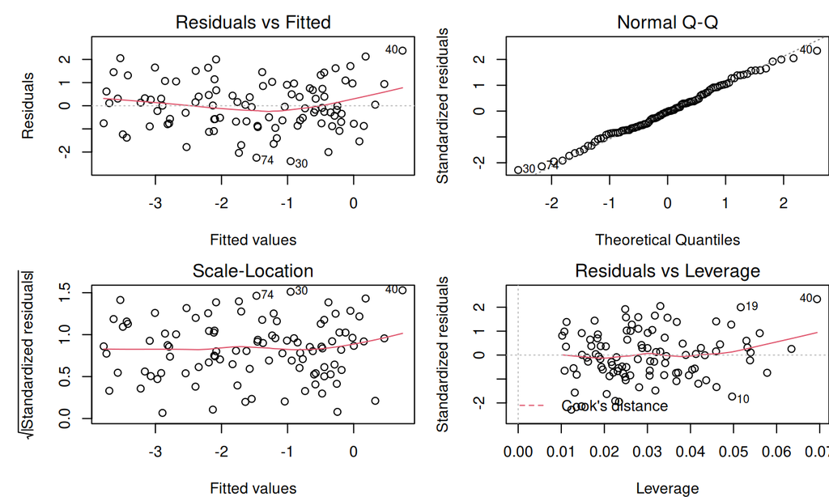

```r
plot(data.add.lm)
```

## Model evaluation

Multiplicative model

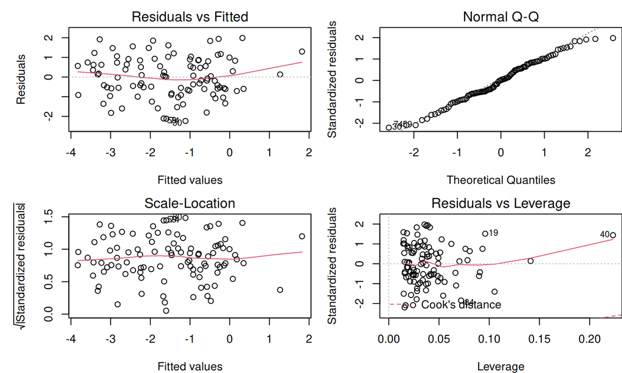

```r
plot(data.mult.lm)
```

## Model summary

Additive model

```r
summary(data.add.lm)
```

```
##
## Call:
## lm(formula = y ~ scale(x1) + scale(x2), data = data)
##
## Residuals:
##      Min       1Q   Median       3Q      Max
## -2.39418 -0.75888 -0.02463  0.73688  2.37938
##
## Coefficients:
##             Estimate Std. Error t value Pr(>|t|)
## (Intercept)  -1.5161     0.1055 -14.364  < 2e-16 ***
## scale(x1)     0.7702     0.1401   5.499  3.1e-07 ***
## scale(x2)    -1.5182     0.1401 -10.839  < 2e-16 ***
## ---
## Signif. codes:  0 '***' 0.001 '**' 0.01 '*' 0.05 '.' 0.1 ' ' 1
##
## Residual standard error: 1.055 on 97 degrees of freedom
## Multiple R-squared:  0.5567, Adjusted R-squared:  0.5476
## F-statistic: 60.91 on 2 and 97 DF,  p-value: < 2.2e-16
```

## Model summary

Additive model

```r
confint(data.add.lm)
```

```
##                  2.5 %    97.5 %
## (Intercept) -1.7255292 -1.306576
## scale(x1)    0.4922116  1.048241
## scale(x2)   -1.7962511 -1.240222
```

## Model summary

Multiplicative model

```r
summary(data.mult.lm)
```

```
##
## Call:
## lm(formula = y ~ scale(x1) * scale(x2), data = data)
##
## Residuals:
##      Min       1Q   Median       3Q      Max
## -2.23364 -0.62188  0.01763  0.80912  1.98568
##
## Coefficients:
##                     Estimate Std. Error t value Pr(>|t|)
## (Intercept)          -1.6995     0.1228 -13.836  < 2e-16 ***
## scale(x1)             0.8146     0.1367   5.957 4.22e-08 ***
## scale(x2)            -1.5648     0.1368 -11.435  < 2e-16 ***
## scale(x1):scale(x2)   0.2837     0.1052   2.697  0.00826 **
## ---
## Signif. codes:  0 '***' 0.001 '**' 0.01 '*' 0.05 '.' 0.1 ' ' 1
##
## Residual standard error: 1.023 on 96 degrees of freedom
## Multiple R-squared:  0.588,  Adjusted R-squared:  0.5751
## F-statistic: 45.66 on 3 and 96 DF,  p-value: < 2.2e-16
```

## Graphical summaries

Additive model

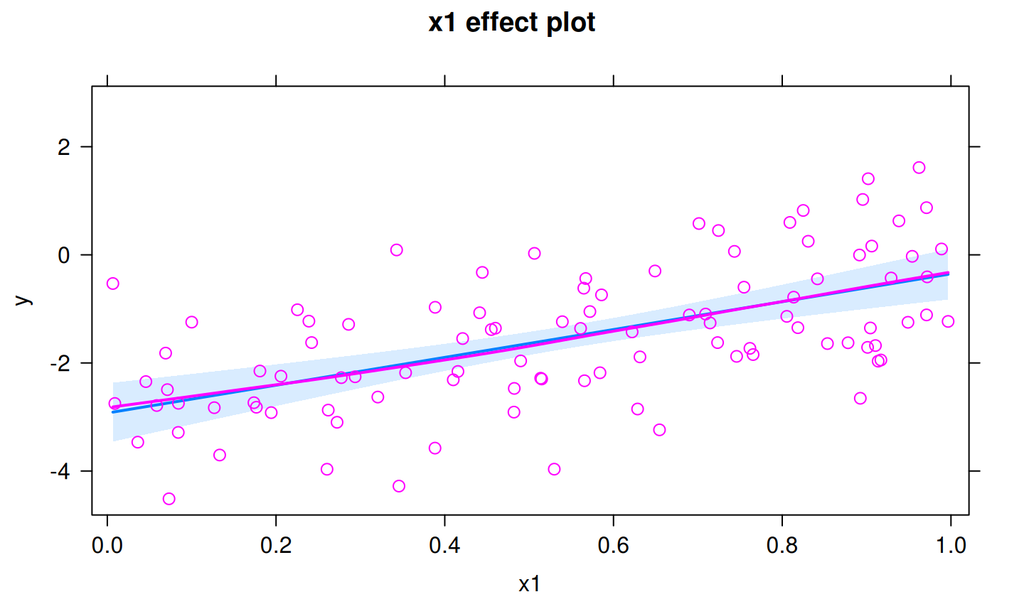

```r
library(effects)
plot(effect("x1",data.add.lm, residuals=TRUE))
```

## Graphical summaries

Additive model

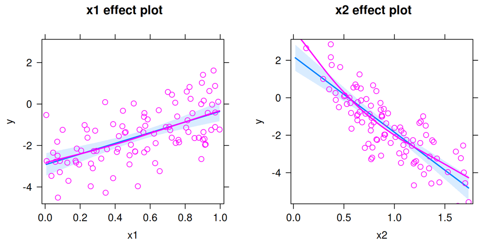

```r
library(effects)
plot(allEffects(data.add.lm, residuals=TRUE))
```

## Graphical summaries

Multiplicative model

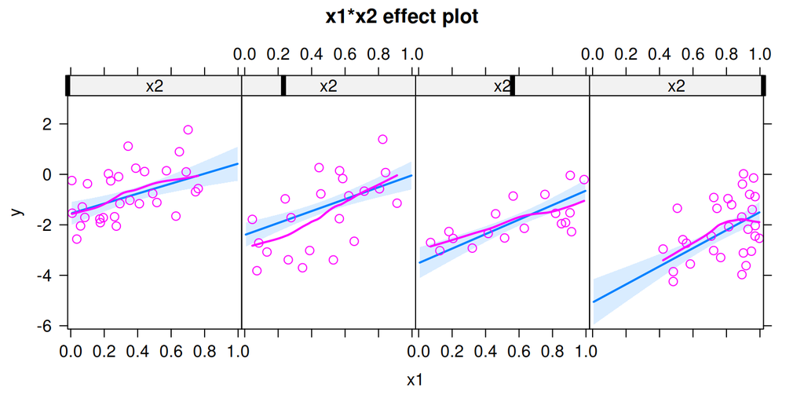

```r
library(effects)
plot(allEffects(data.mult.lm, residuals=TRUE))
```

## Model selection

## How good is a model?

“All models are wrong, but some are useful” George E. P. Box

### Criteria

- \(R^2\) - no
- Information criteria
  - AIC, AICc
  - penalize for complexity

## Model selection

### Candidates

```r
AIC(data.add.lm, data.mult.lm)
```

```
##              df      AIC
## data.add.lm   4 299.5340
## data.mult.lm  5 294.2283
```

```r
library(MuMIn)
AICc(data.add.lm, data.mult.lm)
```

```
##              df     AICc
## data.add.lm   4 299.9551
## data.mult.lm  5 294.8666
```

## Model selection

### Dredging

```r
library(MuMIn)
data.mult.lm <- lm(y~scale(x1)*scale(x2), data, na.action=na.fail)
dredge(data.mult.lm, rank="AICc", trace=TRUE)
```

```
## 0 : lm(formula = y ~ 1, data = data, na.action = na.fail)
## 1 : lm(formula = y ~ scale(x1) + 1, data = data, na.action = na.fail)
## 2 : lm(formula = y ~ scale(x2) + 1, data = data, na.action = na.fail)
## 3 : lm(formula = y ~ scale(x1) + scale(x2) + 1, data = data, na.action = na.fail)
## 7 : lm(formula = y ~ scale(x1) + scale(x2) + scale(x1):scale(x2) +
##     1, data = data, na.action = na.fail)
```

```
## Global model call: lm(formula = y ~ scale(x1) * scale(x2), data = data, na.action = na.fail)
## ---
## Model selection table
##    (Int) scl(x1) scl(x2) scl(x1):scl(x2) df   logLik  AICc delta weight
## 8 -1.699  0.8146  -1.565          0.2837  5 -142.114 294.9  0.00  0.927
## 4 -1.516  0.7702  -1.518                  4 -145.767 300.0  5.09  0.073
## 3 -1.516          -1.015                  3 -159.333 324.9 30.05  0.000
## 1 -1.516                                  2 -186.446 377.0 82.15  0.000
## 2 -1.516 -0.2213                          3 -185.441 377.1 82.27  0.000
## Models ranked by AICc(x)
```

## Multiple Linear Regression

### Model averaging

```r
library(MuMIn)
data.dredge<-dredge(data.mult.lm, rank="AICc")
model.avg(data.dredge, subset=delta<20)
```

```
##
## Call:
## model.avg(object = data.dredge, subset = delta < 20)
##
## Component models:
## '123' '12'
##
## Coefficients:
##        (Intercept) scale(x1) scale(x2) scale(x1):scale(x2)
## full     -1.686125 0.8113591 -1.561395           0.2630362
## subset   -1.686125 0.8113591 -1.561395           0.2836934
```

## Multiple Linear Regression

### Model selection

Or more preferable:

- identify 10-15 candidate models
- compare these via AIC (etc)

## Anova Parameterization

## Categorical predictor

```
##
##
##  Y    A    dummy1   dummy2   dummy3
## ---- ---- -------- -------- --------
##  2    G1     1        0        0
##  3    G1     1        0        0
##  4    G1     1        0        0
##  6    G2     0        1        0
##  7    G2     0        1        0
##  8    G2     0        1        0
##  10   G3     0        0        1
##  11   G3     0        0        1
##  12   G3     0        0        1
```

\[y_{ij}=\mu+\beta_1(dummy_1)_{ij} + \beta_2(dummy_2)_{ij} +\beta_3(dummy_3)_{ij} + \varepsilon_{ij}\]

## Overparameterized

\[y_{ij}=\color{darkorange}{\mu}+\color{darkorange}{\beta_1}(dummy_1)_{ij} + \color{darkorange}{\beta_2}(dummy_2)_{ij} +\color{darkorange}{\beta_3}(dummy_3)_{ij} + \varepsilon_{ij}\]

```
##
##
##  Y    A    Intercept   dummy1   dummy2   dummy3
## ---- ---- ----------- -------- -------- --------
##  2    G1       1         1        0        0
##  3    G1       1         1        0        0
##  4    G1       1         1        0        0
##  6    G2       1         0        1        0
##  7    G2       1         0        1        0
##  8    G2       1         0        1        0
##  10   G3       1         0        0        1
##  11   G3       1         0        0        1
##  12   G3       1         0        0        1
```

## Overparameterized

\[y_{ij}=\color{darkorange}{\mu}+\color{darkorange}{\beta_1}(dummy_1)_{ij} + \color{darkorange}{\beta_2}(dummy_2)_{ij} +\color{darkorange}{\beta_3}(dummy_3)_{ij} + \varepsilon_{ij}\]

- three treatment groups
- **four** parameters to estimate
- need to **re-parameterize**

## Categorical predictor

\[y_{i}=\mu+\beta_1(dummy_1)_{i} + \beta_2(dummy_2)_{} +\beta_3(dummy_3)_{i} + \varepsilon_{i}\]

### Means parameterization

\[y_{i}=\beta_1(dummy_1)_{i} + \beta_2(dummy_2)_{i} +\beta_3(dummy_3)_{i} + \varepsilon_{ij}\] \[y_{ij}=\alpha_i + \varepsilon_{ij} \quad \mathsf{i=p}\]

## Categorical predictor

### Means parameterization

\[y_{i}=\beta_1(dummy_1)_{i} + \beta_2(dummy_2)_{i} +\beta_3(dummy_3)_{i} + \varepsilon_{i}\]

```
##
##
##  Y    A    dummy1   dummy2   dummy3
## ---- ---- -------- -------- --------
##  2    G1     1        0        0
##  3    G1     1        0        0
##  4    G1     1        0        0
##  6    G2     0        1        0
##  7    G2     0        1        0
##  8    G2     0        1        0
##  10   G3     0        0        1
##  11   G3     0        0        1
##  12   G3     0        0        1
```

## Categorical predictor

### Means parameterization

Raw data

Matrix representation

| 2 | G1 |
| --- | --- |
| 3 | G1 |
| 4 | G1 |
| 6 | G2 |
| 7 | G2 |
| 8 | G2 |
| 10 | G3 |
| 11 | G3 |
| 12 | G3 |

\[ y_i = \alpha_1 D_{1i} + \alpha_2 D_{2i} + \alpha_3 D_{3i} + \varepsilon_i\\ y_i = \alpha_p+\varepsilon_i, \\ \text{where}~p= \text{number of levels of the factor}\\\text{and } D = \text{dummy variables}\] \[\begin{pmatrix} 2\\3\\4\\6\\7\\8\\10\\11\\12 \end{pmatrix} = \begin{pmatrix} 1&0&0\\1&0&0\\1&0&0\\0&1&0\\0&1&0\\0&1&0\\0&0&1\\0&0&1\\0&0&1 \end{pmatrix} \times \begin{pmatrix} \alpha_1\\\alpha_2\\\alpha_3 \end{pmatrix} + \begin{pmatrix} \varepsilon_1\\\varepsilon_2\\\varepsilon_3\\\varepsilon_4&\\\varepsilon_5\\\varepsilon_6\\\varepsilon_7&\\\varepsilon_8\\\varepsilon_9 \end{pmatrix} \]

\[\alpha_1 = 3, \alpha_2 = 7, \alpha_3 = 11\]

## Categorical predictor

### Means parameterization

| \(\alpha^*_1\) | mean of group 1 | H\(_0\): \(\alpha_1=\alpha_1=0\) |
| --- | --- | --- |
| \(\alpha^*_2\) | mean of group 2 | H\(_0\): \(\alpha_2=\alpha_2=0\) |
| \(\alpha^*_3\) | mean of group 3 | H\(_0\): \(\alpha_3=\alpha_3=0\) |
| … |  |  |

```r
summary(lm(Y~-1+A))$coef
```

```
##     Estimate Std. Error   t value     Pr(>|t|)
## AG1        3  0.5773503  5.196152 2.022368e-03
## AG2        7  0.5773503 12.124356 1.913030e-05
## AG3       11  0.5773503 19.052559 1.351732e-06
```

- but typically interested exploring **effects**

## Categorical predictor

\[y_{i}=\mu+\beta_1(dummy_1)_{i} + \beta_2(dummy_2)_{i} +\beta_3(dummy_3)_{i} + \varepsilon_{i}\]

### Effects parameterization

\[y_{ij}=\mu+\beta_2(dummy_2)_{ij} + \beta_3(dummy_3)_{ij} + \varepsilon_{ij}\] \[y_{ij}=\mu + \alpha_i + \varepsilon_{ij} \qquad \mathsf{i=p-1}\]

## Categorical predictor

### Effects parameterization

\[y_{i}=\alpha + \beta_2(dummy_2)_{i} +\beta_3(dummy_3)_{i} + \varepsilon_{i}\]

```
##
##
##  Y    A    alpha   dummy2   dummy3
## ---- ---- ------- -------- --------
##  2    G1     1       0        0
##  3    G1     1       0        0
##  4    G1     1       0        0
##  6    G2     1       1        0
##  7    G2     1       1        0
##  8    G2     1       1        0
##  10   G3     1       0        1
##  11   G3     1       0        1
##  12   G3     1       0        1
```

## Categorical predictor

### Effects parameterization

Raw data

Matrix representation

| 2 | G1 |
| --- | --- |
| 3 | G1 |
| 4 | G1 |
| 6 | G2 |
| 7 | G2 |
| 8 | G2 |
| 10 | G3 |
| 11 | G3 |
| 12 | G3 |

\[y_i = \mu + \alpha_p+\varepsilon_i, \\ \text{where}~p= \text{number of levels minus 1}\] \[\begin{pmatrix} 2\\3\\4\\6\\7\\8\\10\\11\\12 \end{pmatrix} = \begin{pmatrix} 1&0&0\\1&0&0\\1&0&0\\1&1&0\\1&1&0\\1&1&0\\1&0&1\\1&0&1\\1&0&1 \end{pmatrix} \times \begin{pmatrix} \mu\\\alpha_2\\\alpha_3 \end{pmatrix} + \begin{pmatrix} \varepsilon_1\\\varepsilon_2\\\varepsilon_3\\\varepsilon_4&\\\varepsilon_5\\\varepsilon_6\\\varepsilon_7&\\\varepsilon_8\\\varepsilon_9 \end{pmatrix} \]

\[\alpha_1 = 3, \alpha_2 = 4, \alpha_3 = 8\]

## Categorical predictor

### Treatment contrasts

| \(Intercept\) | mean of **control** group (\(\mu_1\)) | H\(_0\): \(\mu=\mu_1=0\) |
| --- | --- | --- |
| \(\alpha^*_2\) | mean of group 2 minus mean of **control** group (\(\mu_2-\mu_1\)) | H\(_0\): \(\alpha^*_2=\mu_2-\mu_1=0\) |
| \(\alpha^*_3\) | mean of group 3 minus mean of **control** group (\(\mu_3-\mu_1\)) | H\(_0\): \(\alpha^*_3=\mu_3-\mu_1=0\) |
| … |  |  |

```r
contrasts(A) <-contr.treatment
contrasts(A)
```

```
##    2 3
## G1 0 0
## G2 1 0
## G3 0 1
```

```r
summary(lm(Y~A))$coef
```

```
##             Estimate Std. Error  t value     Pr(>|t|)
## (Intercept)        3  0.5773503 5.196152 2.022368e-03
## A2                 4  0.8164966 4.898979 2.713682e-03
## A3                 8  0.8164966 9.797959 6.506149e-05
```

## Categorical predictor

### Treatment contrasts

| \(Intercept\) | mean of **control** group (\(\mu_1\)) | H\(_0\): \(\mu=\mu_1=0\) |
| --- | --- | --- |
| \(\alpha^*_2\) | mean of group 2 minus mean of **control** group (\(\mu_2-\mu_1\)) | H\(_0\): \(\alpha^*_2=\mu_2-\mu_1=0\) |
| \(\alpha^*_3\) | mean of group 3 minus mean of **control** group (\(\mu_3-\mu_1\)) | H\(_0\): \(\alpha^*_3=\mu_3-\mu_1=0\) |
| … |  |  |

```r
summary(lm(Y~A))$coef
```

```
##             Estimate Std. Error  t value     Pr(>|t|)
## (Intercept)        3  0.5773503 5.196152 2.022368e-03
## A2                 4  0.8164966 4.898979 2.713682e-03
## A3                 8  0.8164966 9.797959 6.506149e-05
```

## Categorical predictor

### User defined contrasts

User defined contrasts  
Grp2 vs Grp3  
Grp1 vs (Grp2 & Grp3)

|  | Grp1 | Grp2 | Grp3 |
| --- | --- | --- | --- |
| \(\alpha_2\) | 0 | 1 | -1 |
| \(\alpha_3\) | 1 | -0.5 | -0.5 |

```r
contrasts(A) <- cbind(c(0,1,-1),c(1, -0.5, -0.5))
contrasts(A)
```

```
##    [,1] [,2]
## G1    0  1.0
## G2    1 -0.5
## G3   -1 -0.5
```

## Categorical predictor

### User defined contrasts

- \(p -1\) comparisons (contrasts)
- all contrasts must be **orthogonal**

## Categorical predictor

### Orthogonality

Four groups (A, B, C, D)

\(p-1=3~\) comparisons

1. A vs B :: A \(>\) B
2. B vs C :: B \(>\) C
3. A vs C ::

## Categorical predictor

### User defined contrasts

```r
contrasts(A) <- cbind(c(0,1,-1),c(1, -0.5, -0.5))
contrasts(A)
```

```
##    [,1] [,2]
## G1    0  1.0
## G2    1 -0.5
## G3   -1 -0.5
```

\[ \begin{array}{rcl} 0\times 1.0 &=& 0\\ 1\times -0.5 &=& -0.5\\ -1\times -0.5 &=& 0.5\\ sum &=& 0 \end{array} \]

## Categorical predictor

### User defined contrasts

```r
contrasts(A) <- cbind(c(0,1,-1),c(1, -0.5, -0.5))
contrasts(A)
```

```
##    [,1] [,2]
## G1    0  1.0
## G2    1 -0.5
## G3   -1 -0.5
```

```r
crossprod(contrasts(A))
```

```
##      [,1] [,2]
## [1,]    2  0.0
## [2,]    0  1.5
```

```r
summary(lm(Y~A))$coef
```

```
##             Estimate Std. Error   t value     Pr(>|t|)
## (Intercept)        7  0.3333333 21.000000 7.595904e-07
## A1                -2  0.4082483 -4.898979 2.713682e-03
## A2                -4  0.4714045 -8.485281 1.465426e-04
```

## Categorical predictor

### User defined contrasts

```r
contrasts(A) <- cbind(c(1, -0.5, -0.5),c(1,-1,0))
contrasts(A)
```

```
##    [,1] [,2]
## G1  1.0    1
## G2 -0.5   -1
## G3 -0.5    0
```

```r
crossprod(contrasts(A))
```

```
##      [,1] [,2]
## [1,]  1.5  1.5
## [2,]  1.5  2.0
```

## Partitioning of variance (ANOVA)

## ANOVA

### Partitioning variance

```r
anova(lm(Y~A))
```

```
## Analysis of Variance Table
##
## Response: Y
##           Df Sum Sq Mean Sq F value    Pr(>F)
## A          2     96      48      48 0.0002035 ***
## Residuals  6      6       1
## ---
## Signif. codes:  0 '***' 0.001 '**' 0.01 '*' 0.05 '.' 0.1 ' ' 1
```

## Categorical predictor

### Post-hoc comparisons

| 3 | 3 | 0.14 |
| --- | --- | --- |
| 5 | 10 | 0.40 |
| 10 | 45 | 0.90 |

## Categorical predictor

### Post-hoc comparisons

Bonferoni

```r
summary(lm(Y~A))$coef
```

```
##             Estimate Std. Error   t value     Pr(>|t|)
## (Intercept)        7  0.3333333 21.000000 7.595904e-07
## A1                -8  0.9428090 -8.485281 1.465426e-04
## A2                 4  0.8164966  4.898979 2.713682e-03
```

```r
0.05/3
```

```
## [1] 0.01666667
```

## Categorical predictor

### Post-hoc comparisons

Tukey’s test

```r
library(emmeans)
data.lm<-lm(Y~A)
emmeans(data.lm, pairwise~A)
```

```
## $emmeans
##  A  emmean    SE df lower.CL upper.CL
##  G1      3 0.577  6     1.59     4.41
##  G2      7 0.577  6     5.59     8.41
##  G3     11 0.577  6     9.59    12.41
##
## Confidence level used: 0.95
##
## $contrasts
##  contrast estimate    SE df t.ratio p.value
##  G1 - G2        -4 0.816  6 -4.899  0.0065
##  G1 - G3        -8 0.816  6 -9.798  0.0002
##  G2 - G3        -4 0.816  6 -4.899  0.0065
##
## P value adjustment: tukey method for comparing a family of 3 estimates
```

## Assumptions

- Normality
- Homogeneity of variance
- Independence
- As for regression